# MD06 Demo, Part I

Load packages and set theme.

```r
library(tidyverse)
library(moderndive)
library(ggthemes)
library(patchwork)
theme_set(theme_light())
```

Let’s look at the MD evaluations data.

```r
data(evals)
glimpse(evals)
```

```
Rows: 463
Columns: 14
$ ID           <int> 1, 2, 3, 4, 5, 6, 7, 8, 9, 10, 11, 12, 13, 14, 15, 16, 17…
$ prof_ID      <int> 1, 1, 1, 1, 2, 2, 2, 3, 3, 4, 4, 4, 4, 4, 4, 4, 4, 5, 5, …
$ score        <dbl> 4.7, 4.1, 3.9, 4.8, 4.6, 4.3, 2.8, 4.1, 3.4, 4.5, 3.8, 4.…
$ age          <int> 36, 36, 36, 36, 59, 59, 59, 51, 51, 40, 40, 40, 40, 40, 4…
$ bty_avg      <dbl> 5.000, 5.000, 5.000, 5.000, 3.000, 3.000, 3.000, 3.333, 3…
$ gender       <fct> female, female, female, female, male, male, male, male, m…
$ ethnicity    <fct> minority, minority, minority, minority, not minority, not…
$ language     <fct> english, english, english, english, english, english, eng…
$ rank         <fct> tenure track, tenure track, tenure track, tenure track, t…
$ pic_outfit   <fct> not formal, not formal, not formal, not formal, not forma…
$ pic_color    <fct> color, color, color, color, color, color, color, color, c…
$ cls_did_eval <int> 24, 86, 76, 77, 17, 35, 39, 55, 111, 40, 24, 24, 17, 14, …
$ cls_students <int> 43, 125, 125, 123, 20, 40, 44, 55, 195, 46, 27, 25, 20, 2…
$ cls_level    <fct> upper, upper, upper, upper, upper, upper, upper, upper, u…
```

We are going to ask whether the “beauty” of an instructor predicts their teaching evaluations.

```r
d <- evals |>
  rename(bty = bty_avg,    # just shorter to type
         sex = gender)     # actually what they have

glimpse(d)
```

```
Rows: 463
Columns: 14
$ ID           <int> 1, 2, 3, 4, 5, 6, 7, 8, 9, 10, 11, 12, 13, 14, 15, 16, 17…
$ prof_ID      <int> 1, 1, 1, 1, 2, 2, 2, 3, 3, 4, 4, 4, 4, 4, 4, 4, 4, 5, 5, …
$ score        <dbl> 4.7, 4.1, 3.9, 4.8, 4.6, 4.3, 2.8, 4.1, 3.4, 4.5, 3.8, 4.…
$ age          <int> 36, 36, 36, 36, 59, 59, 59, 51, 51, 40, 40, 40, 40, 40, 4…
$ bty          <dbl> 5.000, 5.000, 5.000, 5.000, 3.000, 3.000, 3.000, 3.333, 3…
$ sex          <fct> female, female, female, female, male, male, male, male, m…
$ ethnicity    <fct> minority, minority, minority, minority, not minority, not…
$ language     <fct> english, english, english, english, english, english, eng…
$ rank         <fct> tenure track, tenure track, tenure track, tenure track, t…
$ pic_outfit   <fct> not formal, not formal, not formal, not formal, not forma…
$ pic_color    <fct> color, color, color, color, color, color, color, color, c…
$ cls_did_eval <int> 24, 86, 76, 77, 17, 35, 39, 55, 111, 40, 24, 24, 17, 14, …
$ cls_students <int> 43, 125, 125, 123, 20, 40, 44, 55, 195, 46, 27, 25, 20, 2…
$ cls_level    <fct> upper, upper, upper, upper, upper, upper, upper, upper, u…
```

Let’s look at the first few cases.

```r
head(d)
```

```
# A tibble: 6 × 14
     ID prof_ID score   age   bty sex    ethnicity    language rank   pic_outfit
  <int>   <int> <dbl> <int> <dbl> <fct>  <fct>        <fct>    <fct>  <fct>
1     1       1   4.7    36     5 female minority     english  tenur… not formal
2     2       1   4.1    36     5 female minority     english  tenur… not formal
3     3       1   3.9    36     5 female minority     english  tenur… not formal
4     4       1   4.8    36     5 female minority     english  tenur… not formal
5     5       2   4.6    59     3 male   not minority english  tenur… not formal
6     6       2   4.3    59     3 male   not minority english  tenur… not formal
# ℹ 4 more variables: pic_color <fct>, cls_did_eval <int>, cls_students <int>,
#   cls_level <fct>
```

Here’s the regression from last week.

```r
mod1 <- lm(score ~ bty,
           data = d)

get_regression_table(mod1)
```

```
# A tibble: 2 × 7
  term      estimate std_error statistic p_value lower_ci upper_ci
  <chr>        <dbl>     <dbl>     <dbl>   <dbl>    <dbl>    <dbl>
1 intercept    3.88      0.076     51.0        0    3.73     4.03
2 bty          0.067     0.016      4.09       0    0.035    0.099
```

Let’s look at the predictions and residuals.

```r
mod1_preds <- get_regression_points(mod1) #this shows the predicted value from our regression and then the actual value from the data

head(mod1_preds)
```

```
# A tibble: 6 × 5
     ID score   bty score_hat residual
  <int> <dbl> <dbl>     <dbl>    <dbl>
1     1   4.7     5      4.21    0.486
2     2   4.1     5      4.21   -0.114
3     3   3.9     5      4.21   -0.314
4     4   4.8     5      4.21    0.586
5     5   4.6     3      4.08    0.52
6     6   4.3     3      4.08    0.22
```

Here’s the regression line (blue). From the regression table, we can tell that when beauty = 0 (which does not actually mean anything in practice), evaluation would be 3.88. Then, for every “beauty point” it’s another 0.067 evaluation points.

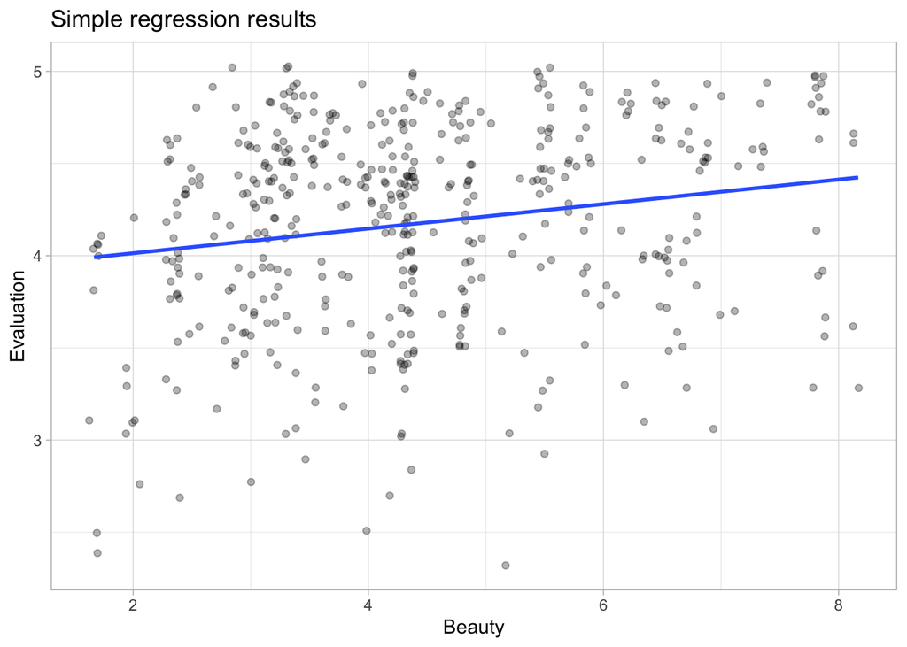

Here are the residuals.

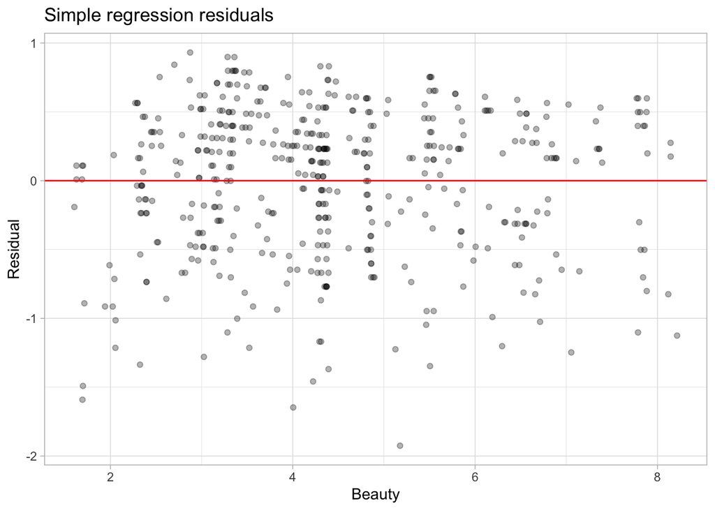

One way to quantify how well a predictor predicts the outcome is to use the **variance**. We’ve seen this already but let’s review. Here’s the formula. $\bar{y}$ is the mean of $y$.

$$V(y) = \frac{1}{n-1}\sum_{i=1}^{n}(y_i - \bar{y})^2$$

Average squared distance between the observation and the mean. Regression is the study of variance, and how we interpret it.

Since our outcome is evaluation score, we can just do that.

```r
var_y <- d |>
  pull(score) |>
  var()

var_y
```

```
[1] 0.2957886
```

This is equivalent to the variance of the “residuals” when we just guess the mean value for every person!

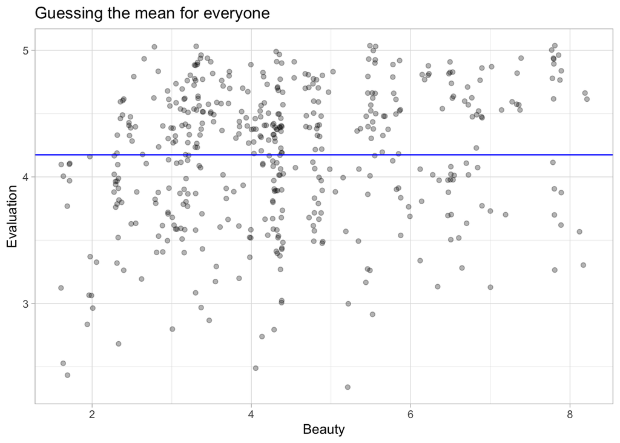

Adding `beauty` as a predictor improves our guess.

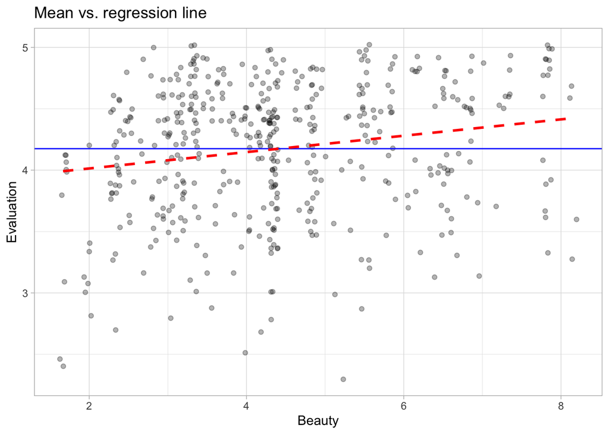

Central argument—I could just guess the average for everyone. Or, I could add a predictor to see if it improves our fit. This is regression.

Now let’s see what the spread looks like if we look at the residuals from the regression line.

```r
var_yhat1 <- mod1_preds |>
  pull(residual) |>
  var()

var_yhat1
```

```
[1] 0.2854513
```

If we take the ratio of these and subtract it from one, that gives us the $R^2$ or “proportion of variance explained” by beauty scores.

```r
1 - (var_yhat1 / var_y)
```

```
[1] 0.03494822
```

It looks like “beauty” can account for about 3.5 percent of the variance in the evaluation scores.

In other words, if we try to guess instructors’ evaluation scores, our guesses will be 3.5 percent *less wrong* on average if we know the instructor’s beauty rating.

We can get this from `broom::glance()` or `moderndive::get_regression_summaries()` without doing it manually. The latter will be a more curated list of things you’ll need for this course.

```r
broom::glance(mod1)
```

```
# A tibble: 1 × 12
  r.squared adj.r.squared sigma statistic   p.value    df logLik   AIC   BIC
      <dbl>         <dbl> <dbl>     <dbl>     <dbl> <dbl>  <dbl> <dbl> <dbl>
1    0.0350        0.0329 0.535      16.7 0.0000508     1  -366.  738.  751.
# ℹ 3 more variables: deviance <dbl>, df.residual <int>, nobs <int>
```

```r
moderndive::get_regression_summaries(mod1)
```

```
# A tibble: 1 × 9
  r_squared adj_r_squared   mse  rmse sigma statistic p_value    df  nobs
      <dbl>         <dbl> <dbl> <dbl> <dbl>     <dbl>   <dbl> <dbl> <dbl>
1     0.035         0.033 0.285 0.534 0.535      16.7       0     1   463
```

```r
max(d$bty) * 0.67 - min(d$bty) * 0.67
```

```
[1] 4.355
```

Let’s try a different predictor. Let’s predict ratings with `sex`.

```r
mod2 <- lm(score ~ sex,
           data = d)

get_regression_table(mod2)
```

```
# A tibble: 2 × 7
  term      estimate std_error statistic p_value lower_ci upper_ci
  <chr>        <dbl>     <dbl>     <dbl>   <dbl>    <dbl>    <dbl>
1 intercept    4.09      0.039    106.     0        4.02     4.17
2 sex: male    0.142     0.051      2.78   0.006    0.042    0.241
```

```r
get_regression_summaries(mod2)
```

```
# A tibble: 1 × 9
  r_squared adj_r_squared   mse  rmse sigma statistic p_value    df  nobs
      <dbl>         <dbl> <dbl> <dbl> <dbl>     <dbl>   <dbl> <dbl> <dbl>
1     0.017         0.014 0.290 0.539  0.54      7.75   0.006     1   463
```

Looks like male instructors get slightly better evaluations but this only accounts for a tiny bit of the of the variance. Don’t be confused however: small amounts of variance can be really important even if they don’t tell the whole story of variability.

In general, we are not going to want to do this with different variables one by one. We want to do **multiple regression**.

```r
mod3 <- lm(score ~ bty + sex,
           data = d)

get_regression_table(mod3)
```

```
# A tibble: 3 × 7
  term      estimate std_error statistic p_value lower_ci upper_ci
  <chr>        <dbl>     <dbl>     <dbl>   <dbl>    <dbl>    <dbl>
1 intercept    3.75      0.085     44.3    0        3.58     3.91
2 bty          0.074     0.016      4.56   0        0.042    0.106
3 sex: male    0.172     0.05       3.43   0.001    0.074    0.271
```

Here’s what this model does.

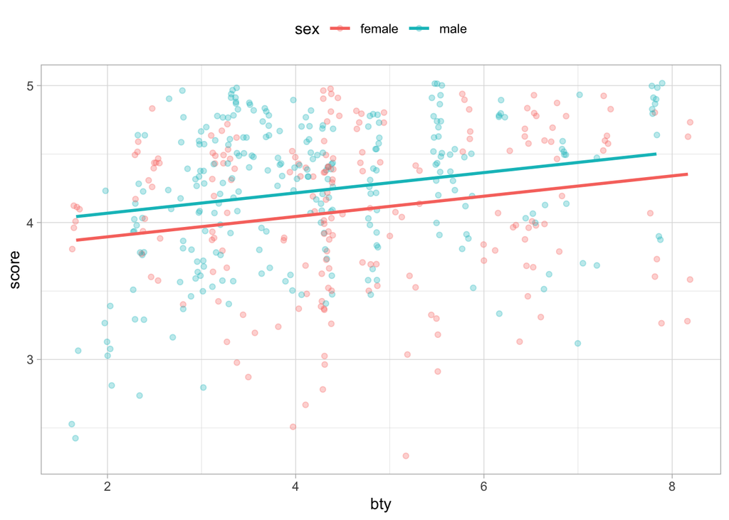

Here’s the formula:

$$\widehat{score}_i = 3.75 + .074(beauty_i) + .172(male_i)$$

We might instead prefer a model like this, which allows the relationship between beauty and evaluations to be *different* for male and female instructors.

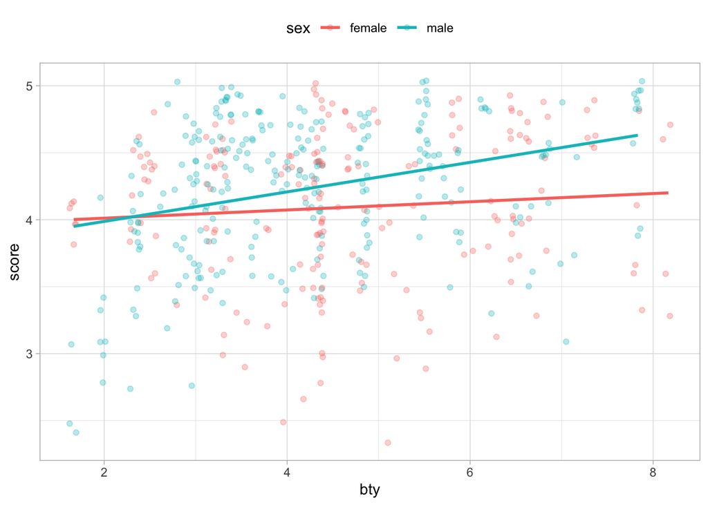

Here’s the syntax, results, and formula.

```r
mod4 <- lm(score ~ bty + sex + bty:sex,
           data = d)

get_regression_table(mod4)
```

```
# A tibble: 4 × 7
  term        estimate std_error statistic p_value lower_ci upper_ci
  <chr>          <dbl>     <dbl>     <dbl>   <dbl>    <dbl>    <dbl>
1 intercept      3.95      0.118     33.5    0        3.72     4.18
2 bty            0.031     0.024      1.28   0.202   -0.017    0.078
3 sex: male     -0.184     0.153     -1.20   0.232   -0.485    0.118
4 bty:sexmale    0.08      0.032      2.45   0.015    0.016    0.143
```

$$\widehat{score}_i = 3.95 + .031(beauty_i) + -.184(male_i) + .080(beauty_i \times male_i)$$
The slope for female instructors is .031. The slope for male instructors is .031 + .080 = .111.

```r
get_regression_summaries(mod3) # parallel
```

```
# A tibble: 1 × 9
  r_squared adj_r_squared   mse  rmse sigma statistic p_value    df  nobs
      <dbl>         <dbl> <dbl> <dbl> <dbl>     <dbl>   <dbl> <dbl> <dbl>
1     0.059         0.055 0.278 0.527 0.529      14.5       0     2   463
```

```r
get_regression_summaries(mod4) # interactions
```

```
# A tibble: 1 × 9
  r_squared adj_r_squared   mse  rmse sigma statistic p_value    df  nobs
      <dbl>         <dbl> <dbl> <dbl> <dbl>     <dbl>   <dbl> <dbl> <dbl>
1     0.071         0.065 0.274 0.524 0.526      11.7       0     3   463
```

Do you think this is an important improvement?

## Now, We Practice!

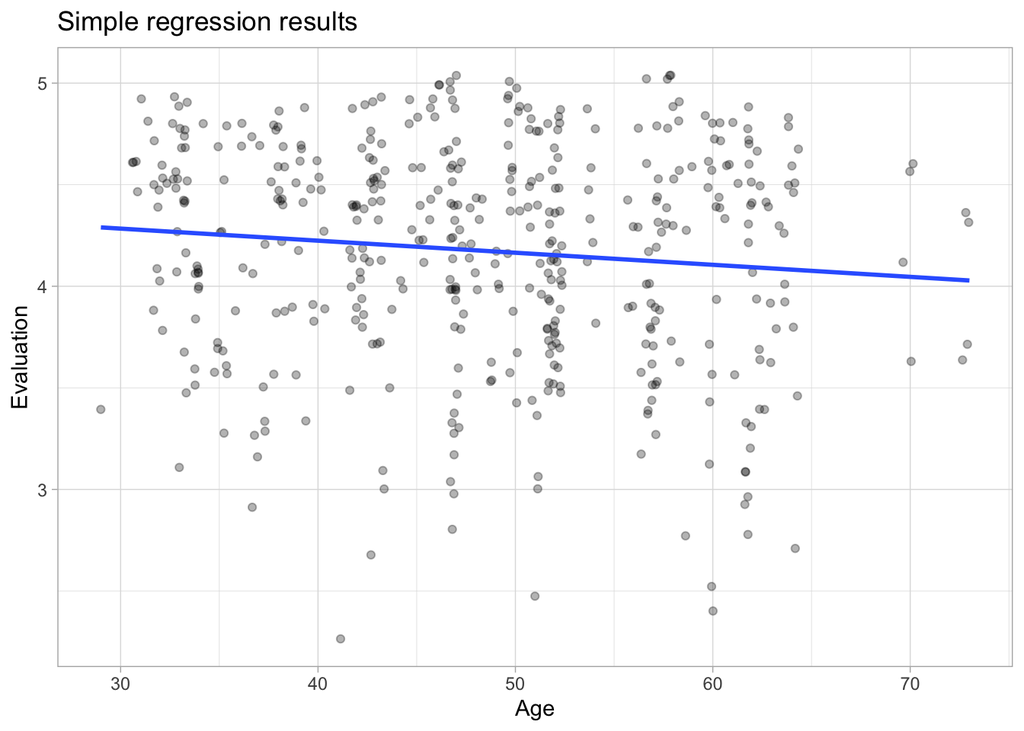

Using a simple regression, it looks like there is a relationship between age and evaluation score. It seems to suggest that older instructors receive lower evaluation scores, in general.

Now, I’m going to get a regression so that I can plot my residuals.

```r
mod2 <- lm(score ~ age,
           data = d)
mod2
```

```
Call:
lm(formula = score ~ age, data = d)

Coefficients:
(Intercept)          age
   4.461932    -0.005938
```

```r
mod2_preds <- get_regression_points(mod2)
head(mod2_preds)
```

```
# A tibble: 6 × 5
     ID score   age score_hat residual
  <int> <dbl> <int>     <dbl>    <dbl>
1     1   4.7    36      4.25    0.452
2     2   4.1    36      4.25   -0.148
3     3   3.9    36      4.25   -0.348
4     4   4.8    36      4.25    0.552
5     5   4.6    59      4.11    0.488
6     6   4.3    59      4.11    0.188
```

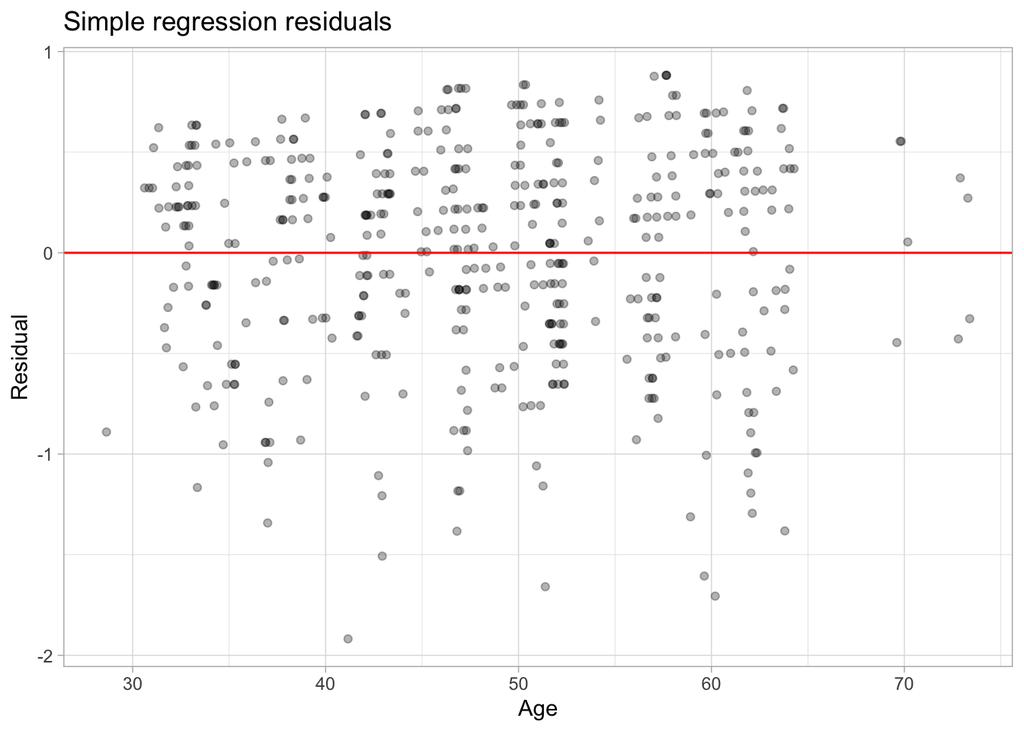

```r
ggplot(mod2_preds,
       aes(x = age,
           y = residual)) +
  geom_jitter(alpha = .3) +
  geom_hline(yintercept = 0,
             color = "red") +
  labs(x = "Age",
       y = "Residual",
       title = "Simple regression residuals")
```

I don’t think that there is any discernible pattern in the residuals, which seems to indicate that this regression is the right method for the data. Now, I’ll be looking at the variance in order to try and see how ‘helpful’ age is as a predictor. From earlier, we know the variance of the score is 0.3, approximately.

```r
var_yhat2 <- mod2_preds |>
  pull(residual) |>
  var()

var_yhat2
```

```
[1] 0.292372
```

```r
1 - (var_yhat2 / var_y)
```

```
[1] 0.01155103
```

```r
round((1 - (var_yhat2 / var_y)) * 100, 1)
```

```
[1] 1.2
```

From what we can see from the data, it appears that age accounts for 1.2% of the variance in evaluation score. Basically, by using age to make a prediction of evaluation score, then our guess will be on average 1.2% less bad than if we had not known age.